# Correction Fiche 2 : Représentation des données avec ggplot2

Septembre 2025

# 4. Exercices

## 4.1 Jeu de données ronfle

### Question 1

Histogramme de l’âge

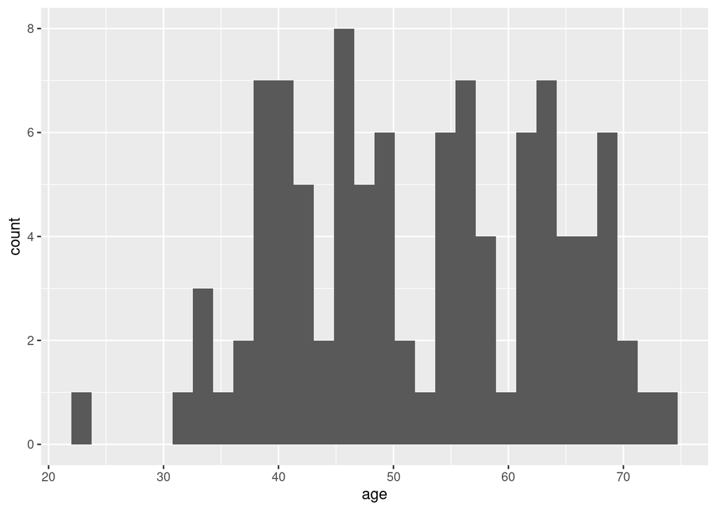

```r
library('ggplot2')
donnees <- read.table(file = "snore.txt", header = T)
ggplot(donnees) + aes(x = age) + geom_histogram()
```

Si on ne veut pas les effectifs par classe d’âge, mais les densités par classe d’âge, on peut procéder comme suit

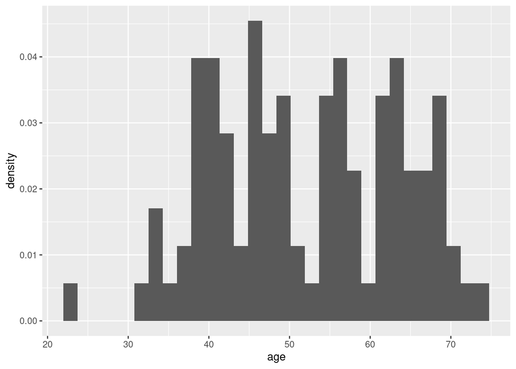

```r
ggplot(donnees) + aes(x = age, y= ..density..) + geom_histogram()
```

### Question 2

L’ajout d’un titre est très simple

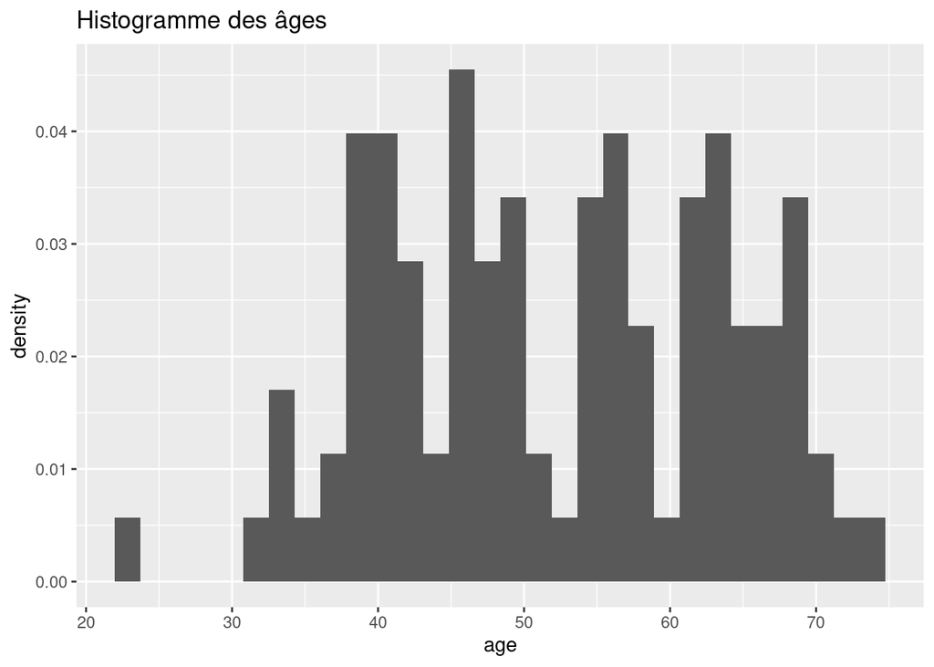

```r
ggplot(donnees) + aes(x = age, y = ..density..) + geom_histogram() + ggtitle("Histogramme des âges")
```

### Question 3

Pour préciser les classes, on utilise l’argument **breaks**

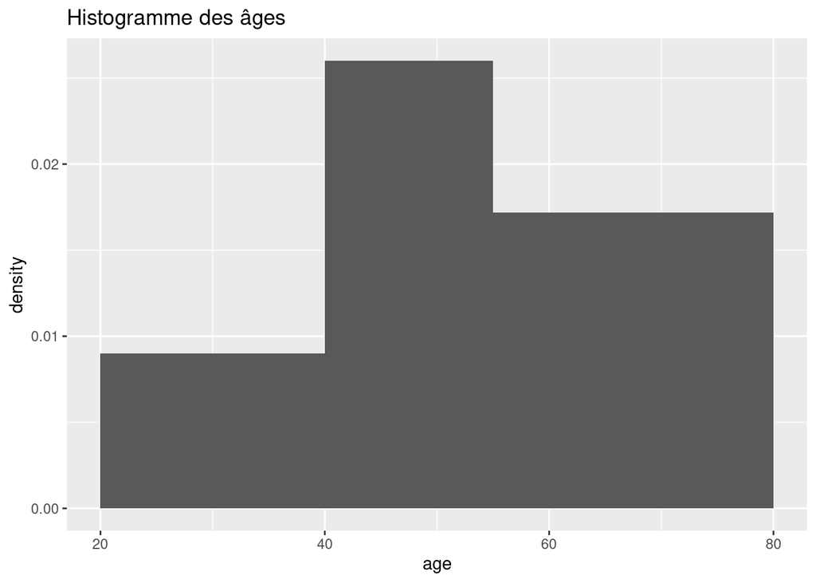

```r
ggplot(donnees)+aes(x = age, y = ..density..) + geom_histogram(breaks = c(20, 40, 55, 80)) + ggtitle("Histogramme des âges")
```

### Question 4

La boîte à moustaches

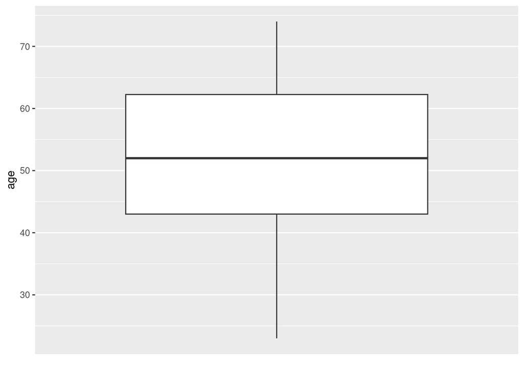

```r
ggplot(data = donnees, aes(x = factor(0), y = age)) + geom_boxplot() + xlab("") + scale_x_discrete(breaks = NULL)
```

### Question 5

Pour subdiviser en plusieurs figures, on utilise le package **gridExtra** (à installer si besoin)

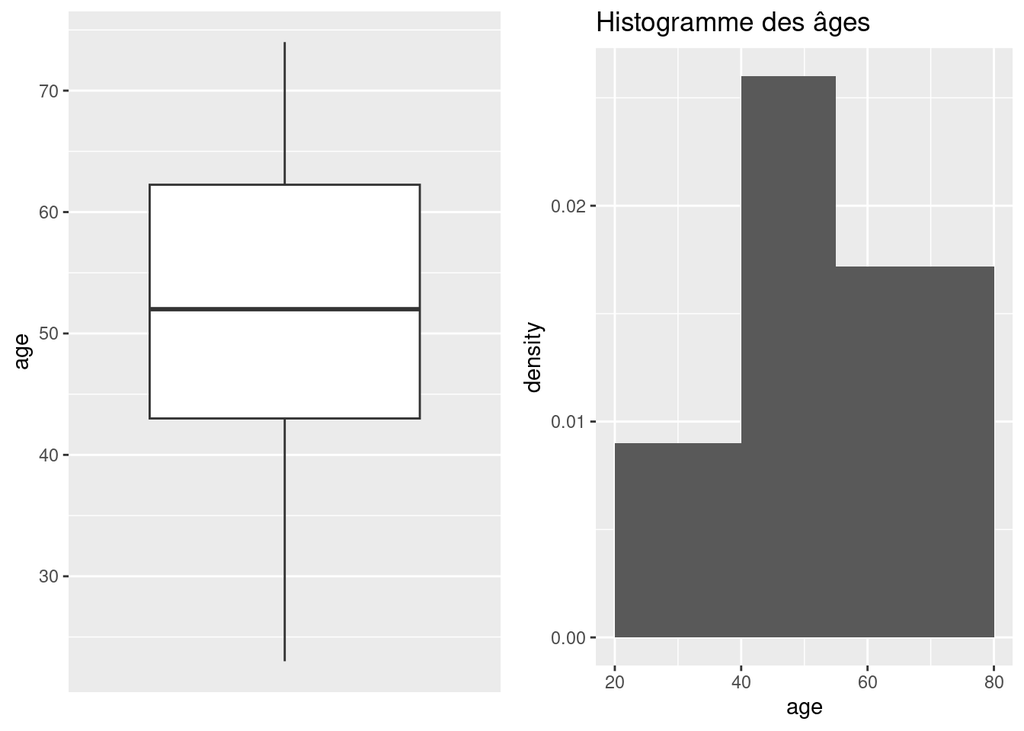

```r
library(gridExtra)
plot1 <- ggplot(data = donnees, aes(x = factor(0), y = age)) + geom_boxplot()
plot1 <- plot1 + xlab("") + scale_x_discrete(breaks = NULL)
plot2 <- ggplot(donnees) + aes(x = age, y = ..density..)
plot2 <- plot2 + geom_histogram(breaks = c(20, 40, 55, 80)) + ggtitle("Histogramme des âges")
grid.arrange(plot1, plot2, nrow = 1, ncol = 2)
```

### Question 6

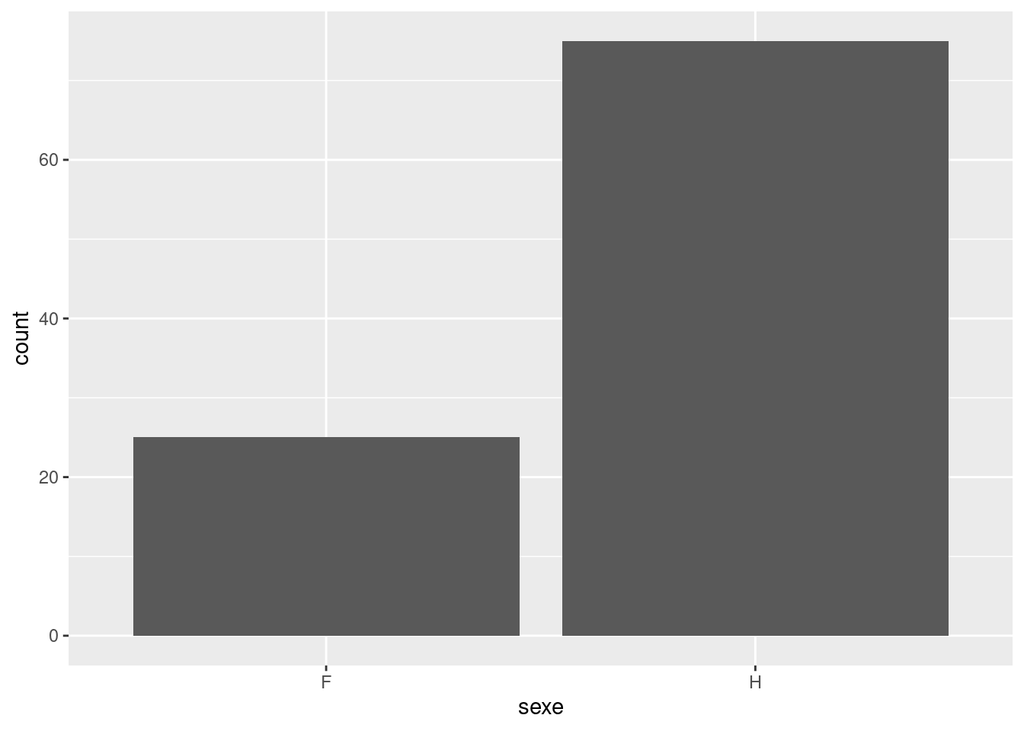

```r
ggplot(donnees) + aes(x = sexe) + geom_bar()
```

Une autre solution consiste à utiliser la fonction **qplot**

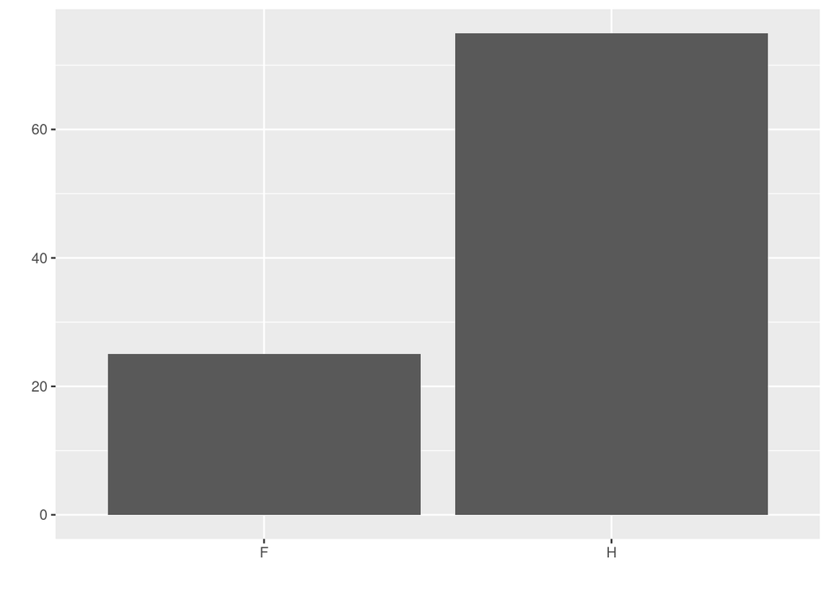

```r
qplot(donnees$sexe, xlab = "")
```

### Question 7

Un diagramme en barres pour la variable quantitative discrète **alcool** s’obtient très facilement

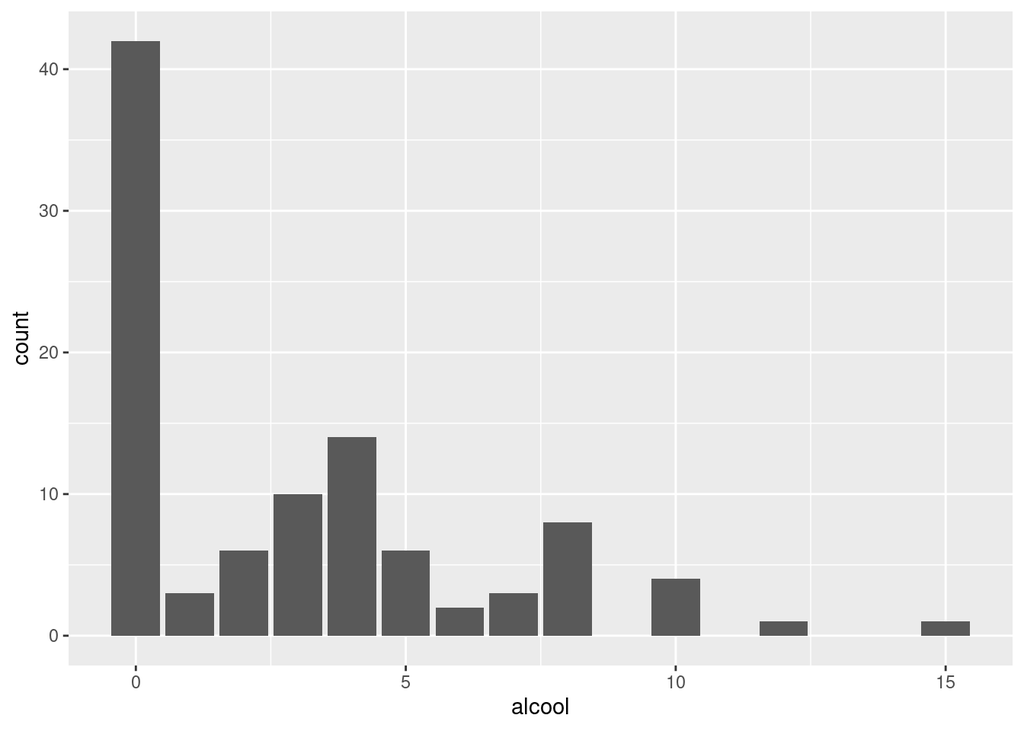

```r
ggplot(donnees) + aes(x = alcool) + geom_bar()
```

```r
ggplot(donnees) + aes(x = as.factor(alcool)) + geom_bar()
```

[output not shown]

### Question 8

Représentation du poids en fonction de la taille :

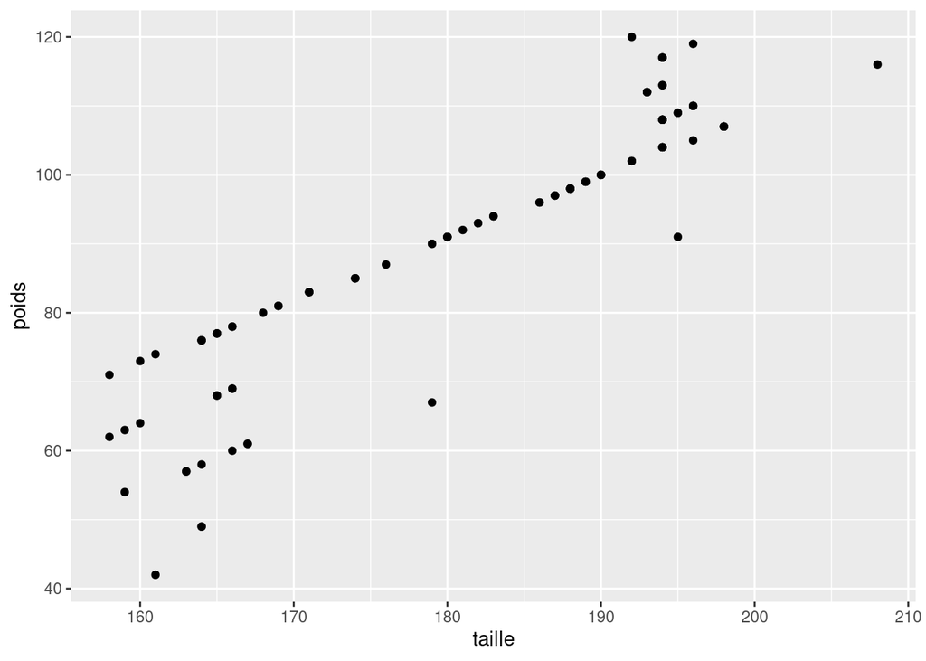

```r
g1 <- ggplot(donnees) + aes(x = taille, y = poids) + geom_point()
g1
```

### Question 9

Représentation de la variable **age** en fonction de la variable **ronfle** :

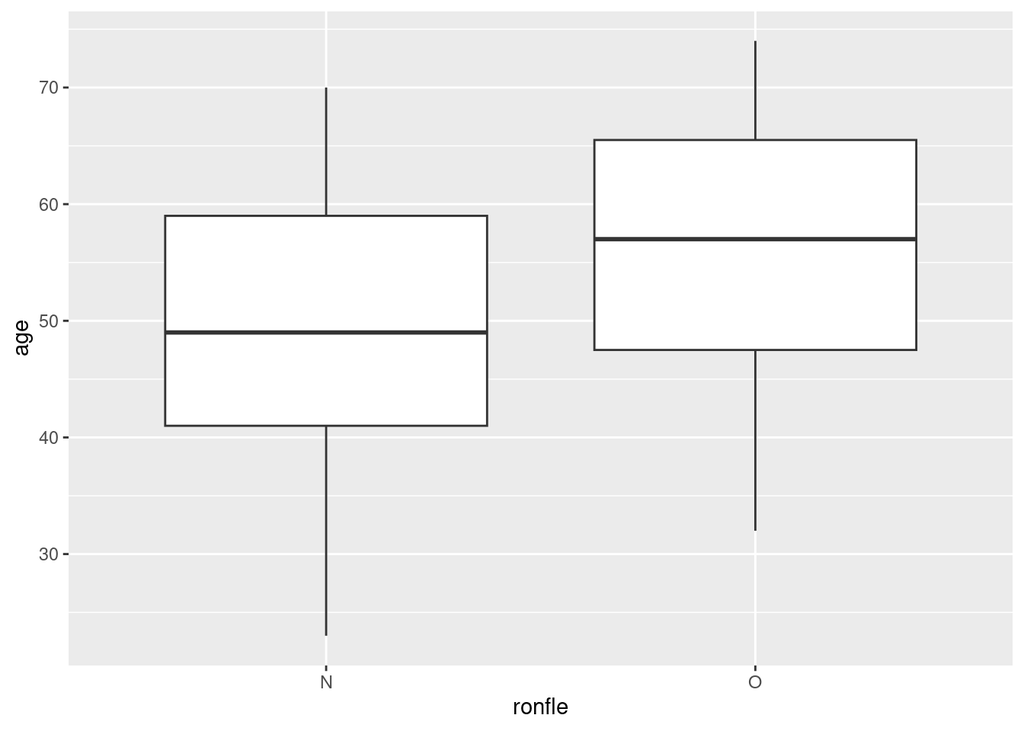

```r
ggplot(donnees) + aes(x = ronfle, y = age) + geom_boxplot()
```

Conclusion : les ronfleurs sont en moyenne plus âgés.

# 4.2 Graphes de fonctions

### Question 1

Tracé de la fonction sinus :

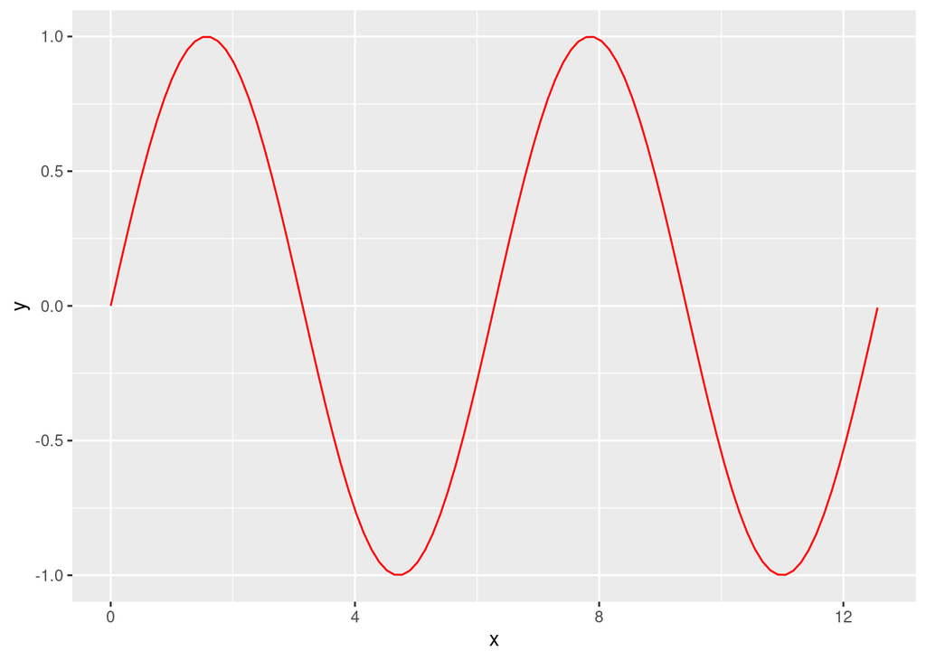

```r
g1 <- ggplot(data.frame(x = seq(0, 4*pi, by = 0.01)), aes(x = x))
g1 <- g1 + stat_function(fun = sin, color = "red")
g1
```

### Question2

Superposition de la fonction cosinus :

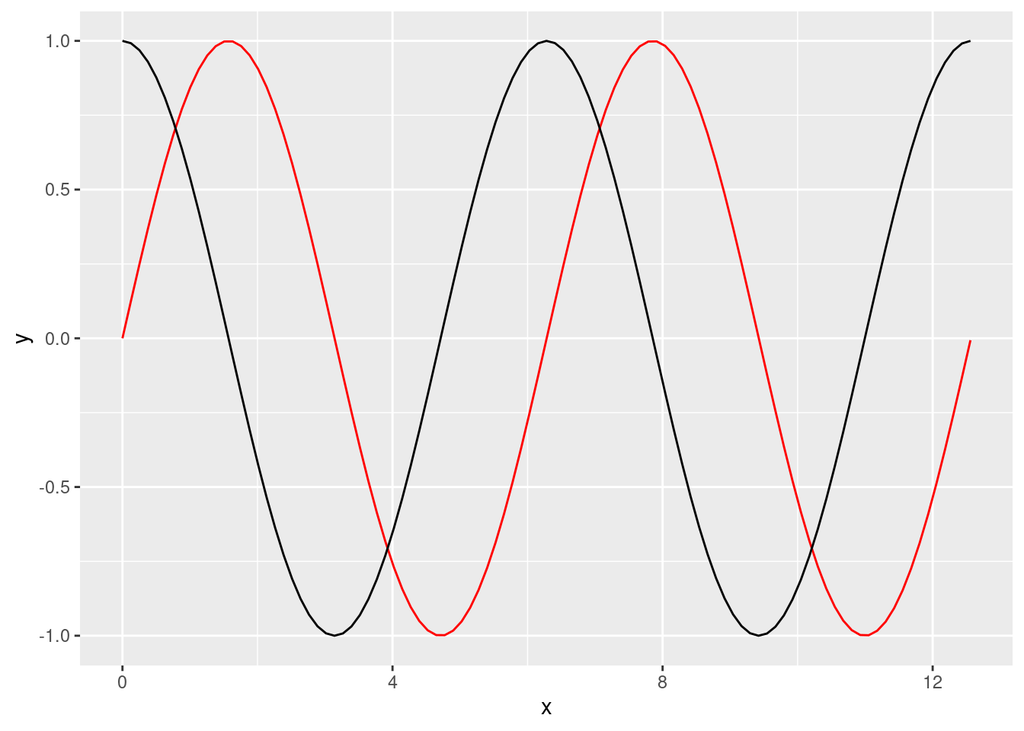

```r
g2 <- g1 + stat_function(fun = cos)
g2
```

### Question 3

Ajout des deux droites

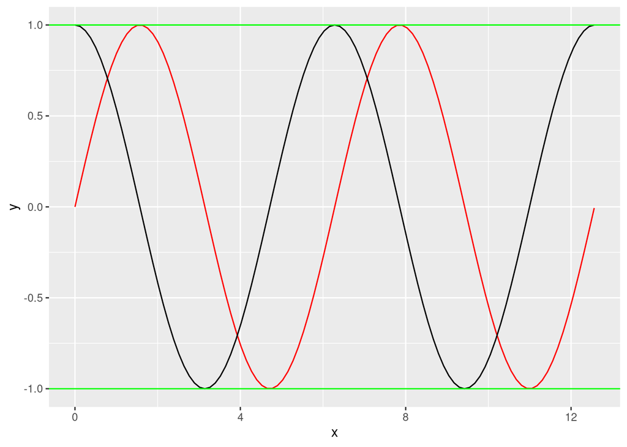

```r
g3 <- g2 + geom_hline(yintercept = c(-1, 1), col = "green")
g3
```

### Question 4

Ajout de la droite d’équation $y=x$ :

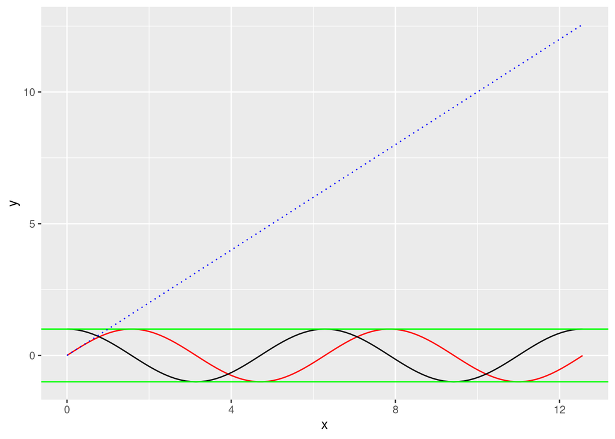

```r
id <- function(x){x}
g4 <- g3 + stat_function(fun = id,color = "blue",linetype = 3)
# g4 <- g3 + stat_function(fun = id,color = "blue",linetype = "dashed")
g4
```

## 4.3. Comparaisons de variables

On souhaite comparer la distribution des variables **taille** et **poids** suivant les modalités de la variable **ronfle**.

### Question 1

Comparaison de la distribution de la variable **taille** suivant les modalités de la variable **ronfle** à l’aide d’un boxplot :

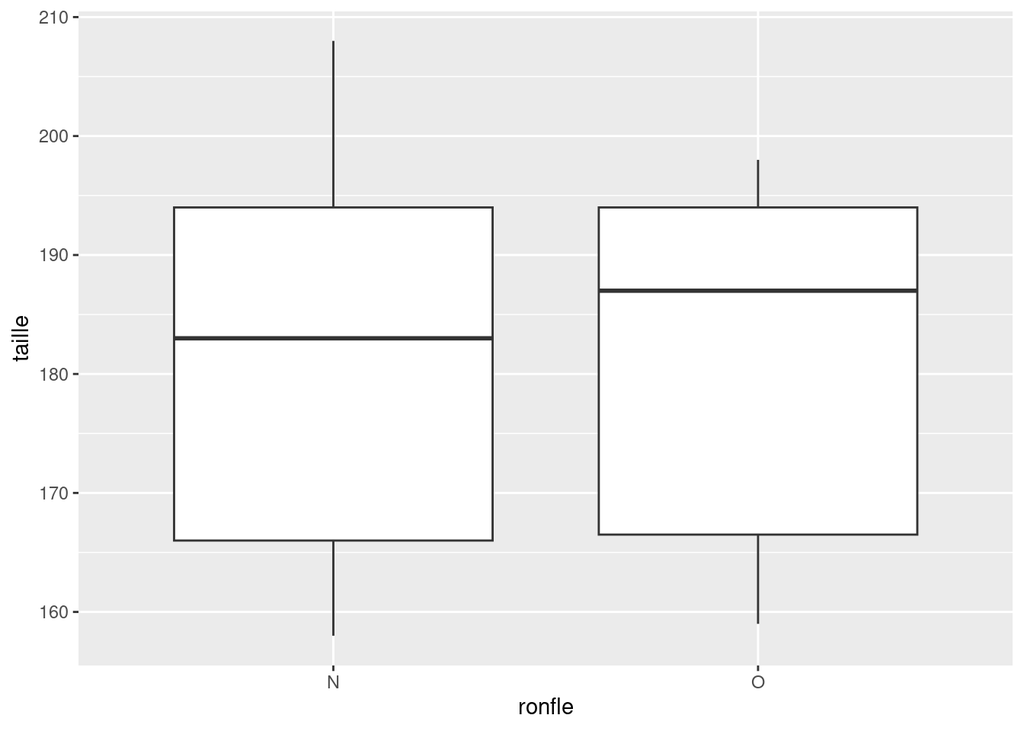

```r
g1 <- ggplot(donnees) + aes(x = ronfle, y = taille) + geom_boxplot()
g1
```

Le fait de ronfler ou non semble indépendant de la taille.

### Question 2

Pour la variable poids, même conclusion :

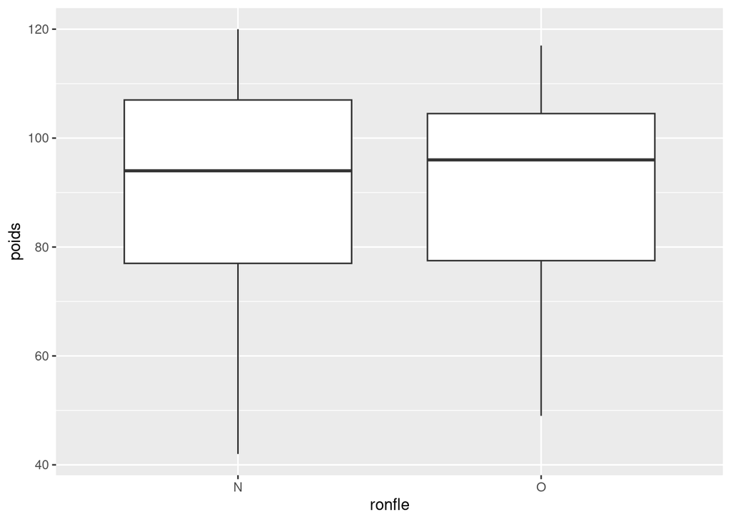

```r
g2 <- ggplot(donnees) + aes(x = ronfle, y = poids) + geom_boxplot()
g2
```

### Question 3

Juxtaposition des deux figures :

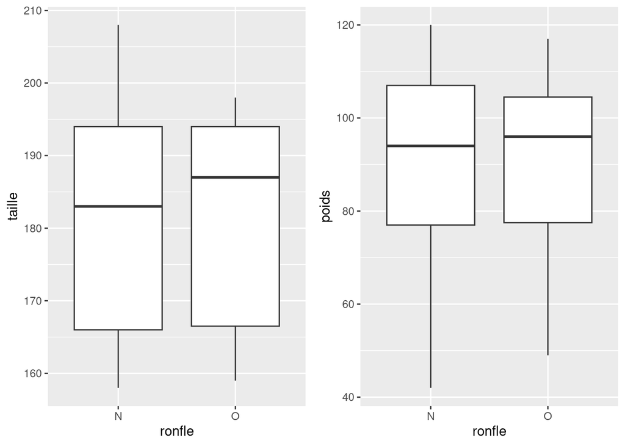

```r
library(gridExtra)
plot1 <- g1
plot2 <- g2
grid.arrange(plot1, plot2, nrow = 1, ncol = 2)
```

## Exercice 4

```r
load("Harry.Rdata")
head(Harry)
```

```
## # A tibble: 6 × 6
##   Num_chap Livre               Chap Personnage Nb_rep Livre_num
##      <int> <fct>              <int> <chr>       <int> <fct>
## 1        1 philosophers_stone     1 Harry          20 beta[ 1 ]
## 2        2 philosophers_stone     2 Harry          79 beta[ 1 ]
## 3        3 philosophers_stone     3 Harry          68 beta[ 1 ]
## 4        4 philosophers_stone     4 Harry          48 beta[ 1 ]
## 5        5 philosophers_stone     5 Harry         147 beta[ 1 ]
## 6        6 philosophers_stone     6 Harry         117 beta[ 1 ]
```

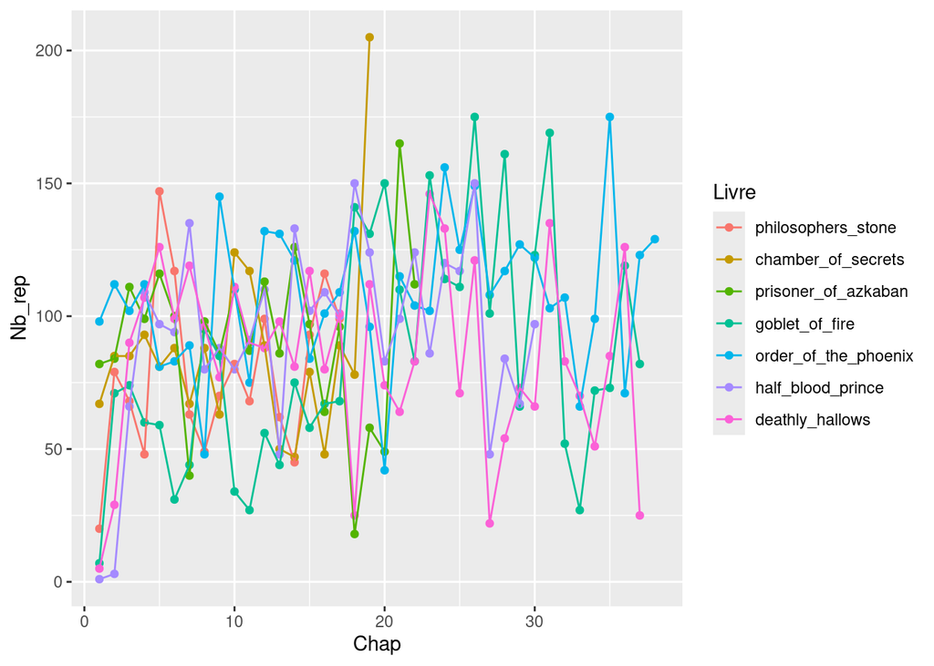

```r
ggplot(Harry, aes(x = Chap, y = Nb_rep, color = Livre)) + geom_point() + geom_line()
```

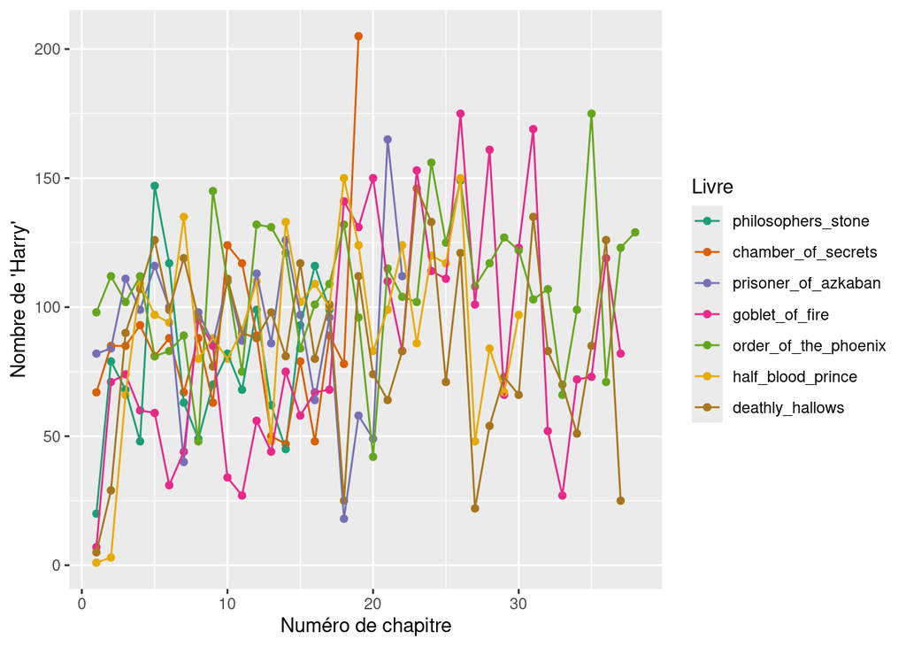

```r
ggplot(Harry, aes(x = Chap, y = Nb_rep, color = Livre)) + geom_point() + geom_line()+
  scale_color_brewer(palette = "Dark2")+
  xlab ("Numéro de chapitre") +
  ylab("Nombre de 'Harry'")
```

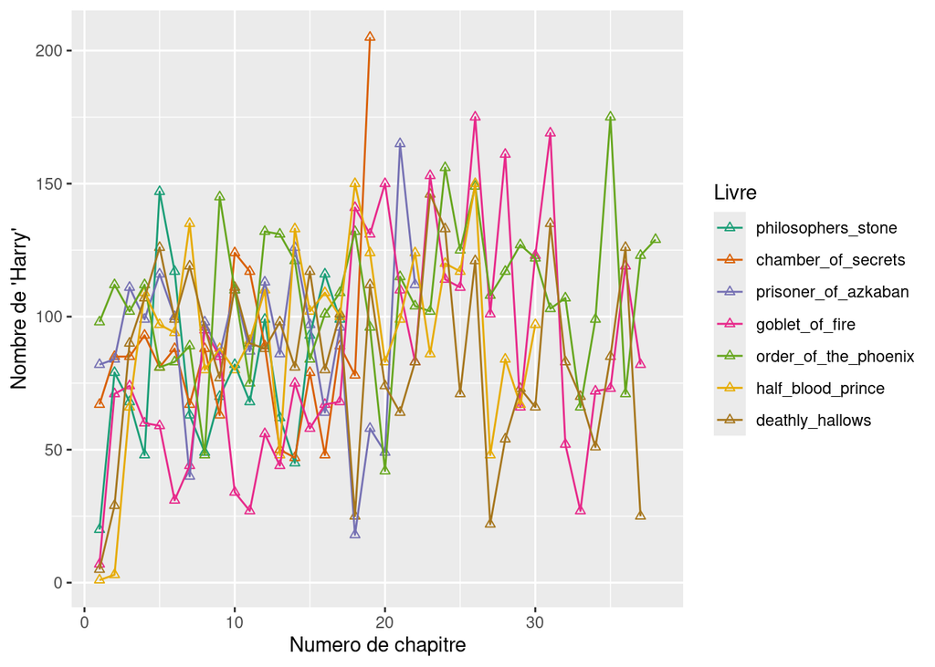

```r
p <- ggplot(data = Harry, aes(x = Chap, y = Nb_rep,color = Livre )) +
  geom_point( shape = 2) +
  geom_line() + scale_color_brewer(palette = "Dark2")+
  xlab ("Numero de chapitre") +
  ylab("Nombre de 'Harry'")
p
```

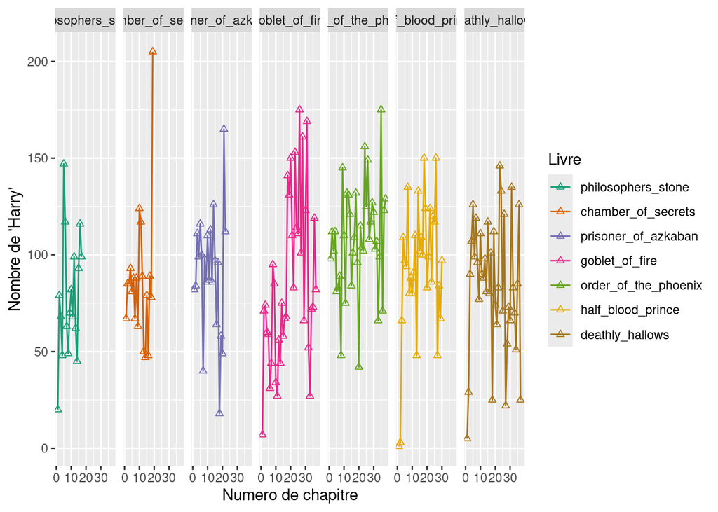

```r
p <- ggplot(data = Harry, aes(x = Chap, y = Nb_rep,color = Livre )) + facet_grid(.~Livre)+
  geom_point( shape = 2) +
  geom_line() + scale_color_brewer(palette = "Dark2")+
  xlab ("Numero de chapitre") +
  ylab("Nombre de 'Harry'")
p
```

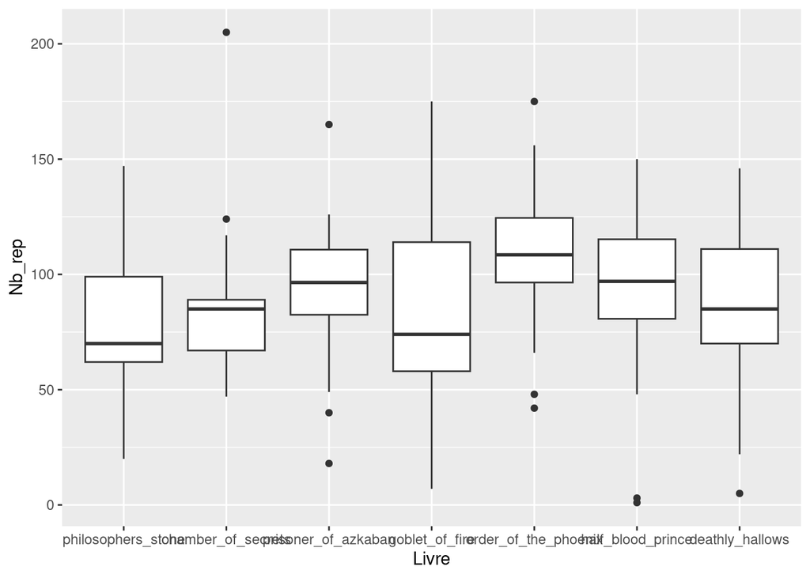

```r
p2 <- ggplot(data = Harry, aes(x = Livre, y = Nb_rep))
p2 + geom_boxplot()
```

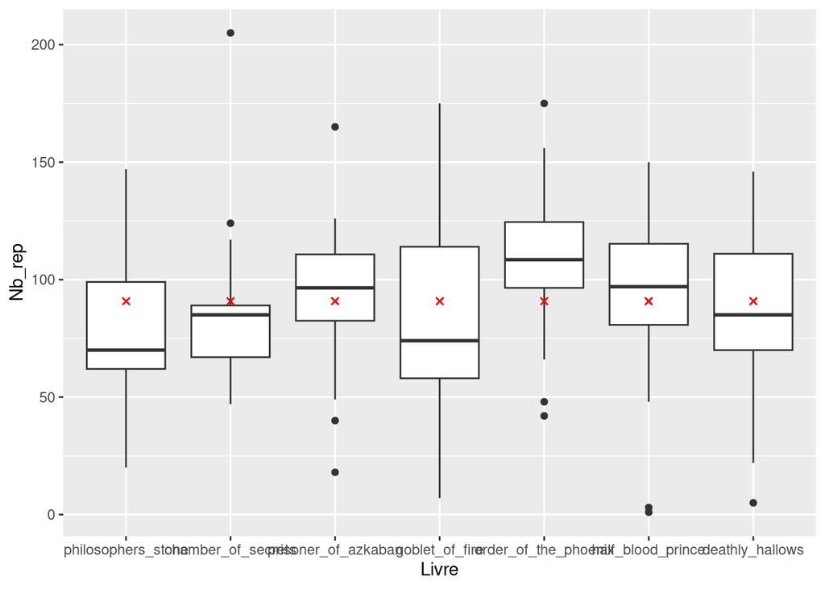

```r
p2 <- ggplot(data = Harry, aes(x = Livre))
p2 + geom_boxplot(aes(y=Nb_rep)) + geom_point(aes(y=mean(Nb_rep)),color="red",shape=4)
```

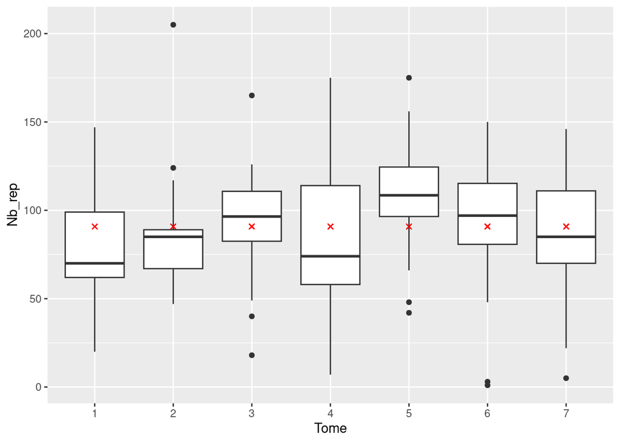

```r
 ggplot(data = Harry, aes(x = Livre)) + geom_boxplot(aes(y=Nb_rep)) + scale_x_discrete(labels=seq(1,7,1))+ geom_point(aes(y=mean(Nb_rep)),color="red",shape=4)+xlab("Tome")
```